**Last updated:** 2016-05-10

**Code version:** 5238faba5f48c4dd40de36aff9a0e23341fdea3b

## Objectives

I want to look at the trans eQTLs that we identify in both sun-exposed lower leg and non-sun-exposed suprapubic skin. Since these tissues are similar, we should (in theory) see similar trans-eQTLs in both tissues.

## Determine Overlap in Tissues

The perl script Overlap2Networks.pl looks for overlap in eQTLs between two tissues. It gives the number of trans-eQTLs that are shared across tissues. It also looks for gene-gene correlation networks that are similar across tissues and looks at the eQTL sharing in those networks. The idea here is if we have two identical networks defined apriori, then we should see similar trans-eQTLs in those networks across tissues.

```bash
perl Overlap2Networks.pl ../output/cis_summary_data/skinnotsunexposedsuprapubic/thresh_60 ../output/cis_summary_data/skinsunexposedlowerleg/thresh_60
```

13% overlap, 193 shared gene-gene correlation networks

```bash
 perl Overlap2Networks.pl ../output/cis_summary_data/muscleskeletal/thresh_80 ../output/cis_summary_data/adiposesubcutaneous/thresh_80
```

13% overlap, 23 shared gene-gene correlation networks

```bash
perl Overlap2Networks.pl ../output/cis_summary_data/braincaudatebasalganglia/thresh_60 ../output/cis_summary_data/braincaudatebasalganglia/thresh_60
```

## Grab functions

Source Gibbs Sampler and Bayes Factor functions.

```r
source("../R/SimulateNetworkExpression.R")  #Compute Bayes factors
source("../R/directionality_CGM.R")    #Gibbs Sampler
library('gtools')
```

## Input file

```r
overlap.file <- "skinnotsunexposedsuprapubic_skinsunexposedlowerleg.OverlapeQTL.txt"
X <- data.frame(read.table(overlap.file, sep="\t", dec=".", comment.char="#", header=T))
```

## Plot Results

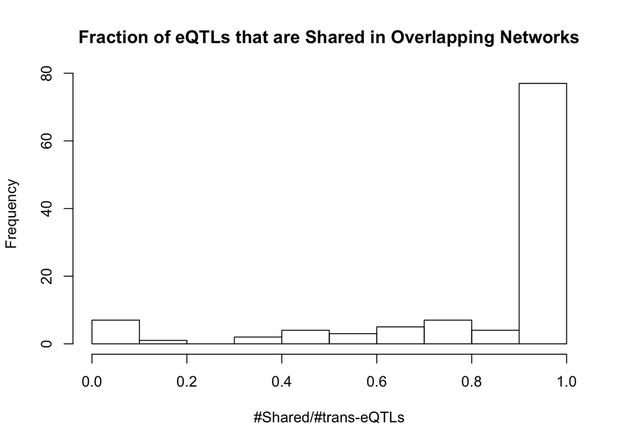

```r
ind.nonzero <- which(X$trans.eQTLs_T1 != 0 & X$trans.eQTLs_T2 != 0)
X.nonzero <- X[ind.nonzero,]
N.eQTLs <- apply(cbind(X.nonzero$trans.eQTLs_T1, X.nonzero$trans.eQTLs_T2), 1, min)
ind.1 <- which(N.eQTLs == 1)
frac.shared <- X.nonzero$Shared_trans.eQTLs/N.eQTLs
frac.shared.no1 <- frac.shared[-ind.1]

hist(frac.shared, main="Fraction of eQTLs that are Shared in Overlapping Networks", xlab="#Shared/#trans-eQTLs")
```

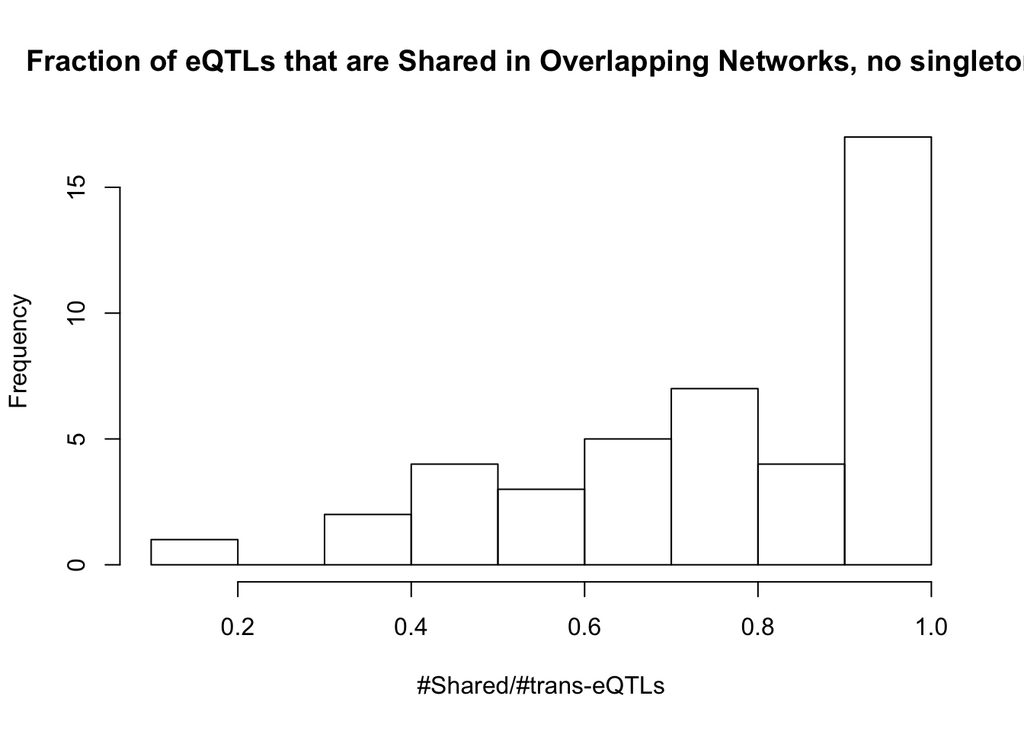

```r
hist(frac.shared.no1, main="Fraction of eQTLs that are Shared in Overlapping Networks, no singletons", xlab="#Shared/#trans-eQTLs")
```